# Analyzing Pima Indians Diabetes

# 1 Introduction

Diabetes is a health condition that is caused by excessive glucose levels in blood. Research shows that more than half the Pima Indians over 35 years of age have type 2 diabetes<sup>1</sup>. Hence we decided to work with the Pima Indians’ Diabetes dataset<sup>2</sup> as furthermore, according to the CDC<sup>3</sup>, diabetes was found to have been more prevalent in women than men. Statistics from the World Health Organisation showed the number of people diagnosed with diabetes have significantly rose from 108 million to 422 million in 2014<sup>4</sup> which is a concerning number. Hence the main objective of our study is to determine which factors have the most significant impact on diabetes in women specifically. Common types of diabetes<sup>5</sup> include Type 1, Type 2 and Gestational Diabetes. Type 1 involves inability to produce glucose which is usually an inherited condition. Type 2 involves the underproduction of insulin to regulate the amount of glucose which is usually preventable while gestational diabetes is diabetes that is diagnosed during pregnancy. The study will be in accordance with these study questions that would provide a more thorough research to achieve the main objective:

1. Which variables have a correlation with one another?
2. Which variable(s) affect the variable ‘glucose’ directly, considering glucose levels directly impact diabetes.

# 2 Methods

## 2.1 Data preparation

In this project, we are concerned with finding the variables that have a direct relationship with diabetes and we will work with the diabetes data containing information of PIMA Indian females, 21 years and above. The dataset specifically contains information of 768 females. There are a total of 9 variables, one of which is the outcome categorical variable, ‘diabetes’, where “pos” is inputted if diabetes is present and “neg” is inputted if diabetes is not present. The other 8 numeric variables include ‘pregnant’, ‘glucose’, ‘pressure’, ‘triceps’, ‘insulin’, ‘mass’, ‘pedigree’ and ‘age’.

```r
library(mlbench)
```

```r
library(ggplot2)
library(corrplot)
library(dplyr)
library(caret)
library(gridExtra)
data("PimaIndiansDiabetes")
summary(PimaIndiansDiabetes)
```

```
##     pregnant         glucose         pressure         triceps
##  Min.   : 0.000   Min.   :  0.0   Min.   :  0.00   Min.   : 0.00
##  1st Qu.: 1.000   1st Qu.: 99.0   1st Qu.: 62.00   1st Qu.: 0.00
##  Median : 3.000   Median :117.0   Median : 72.00   Median :23.00
##  Mean   : 3.845   Mean   :120.9   Mean   : 69.11   Mean   :20.54
##  3rd Qu.: 6.000   3rd Qu.:140.2   3rd Qu.: 80.00   3rd Qu.:32.00
##  Max.   :17.000   Max.   :199.0   Max.   :122.00   Max.   :99.00
##     insulin           mass          pedigree           age        diabetes
##  Min.   :  0.0   Min.   : 0.00   Min.   :0.0780   Min.   :21.00   neg:500
##  1st Qu.:  0.0   1st Qu.:27.30   1st Qu.:0.2437   1st Qu.:24.00   pos:268
##  Median : 30.5   Median :32.00   Median :0.3725   Median :29.00
##  Mean   : 79.8   Mean   :31.99   Mean   :0.4719   Mean   :33.24
##  3rd Qu.:127.2   3rd Qu.:36.60   3rd Qu.:0.6262   3rd Qu.:41.00
##  Max.   :846.0   Max.   :67.10   Max.   :2.4200   Max.   :81.00
```

## 2.2 Dealing with zero values

Due to the zero values in ‘glucose’, ’pressure’, ’triceps’, ’insulin’ and ’mass’, we will replace these values with NA. As removing all the missing values would result in significant information loss, we used the kNN imputation method which adopts the k-Nearest Neighbours approach. The missing values can then be estimated using completed values of neighboring observations<sup>6</sup>. We use the function kNN(data,variable,k) to impute all the missing values. “PimaIndiansDiabetes1” is created which contains all the imputed values.

```r
#Replace zero values by NA
PimaIndiansDiabetes$glucose[ PimaIndiansDiabetes$glucose == 0 ] <- NA
PimaIndiansDiabetes$pressure[ PimaIndiansDiabetes$pressure == 0 ] <- NA
PimaIndiansDiabetes$triceps[ PimaIndiansDiabetes$triceps == 0 ] <- NA
PimaIndiansDiabetes$insulin[ PimaIndiansDiabetes$insulin == 0 ] <- NA
PimaIndiansDiabetes$mass[ PimaIndiansDiabetes$mass == 0 ] <- NA

#kNN imputation
library(VIM)
PimaIndiansDiabetes1<-kNN(PimaIndiansDiabetes,
                         variable=c("glucose","pressure",
                                    "triceps","insulin","mass"),k=5)
PimaIndiansDiabetes1<-select(PimaIndiansDiabetes1,pregnant:diabetes)
```

## 2.3 Preliminary Exploratory Analysis

Exploring the new dataset, we made use of a bar graph (See Figure 2.1) to analyse the proportion of women that were found to have been diagnosed with diabetes. There were 500 women who tested negative and 268 women tested positive for diabetes which indicated a significant proportion testing positive still.

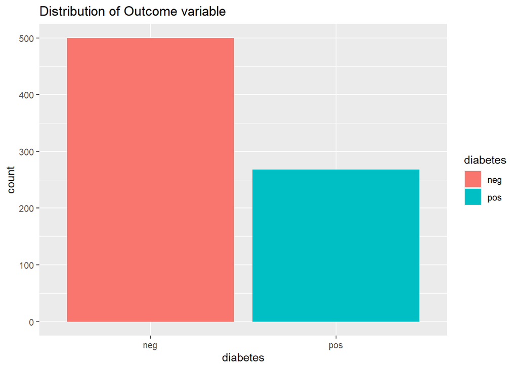

```r
ggplot(PimaIndiansDiabetes1,aes(x=diabetes,fill = diabetes )) + geom_bar() + ggtitle("Distribution of Outcome variable")
```

We coded for the correlation matrix to analyse the relationship between the numerical variables, hence dealing with our first study question.

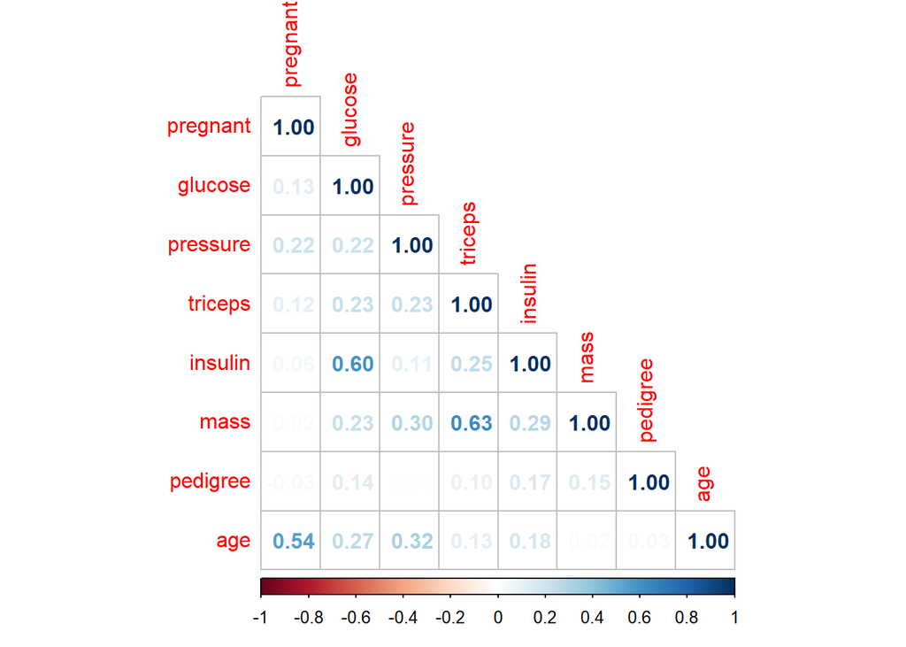

Figure 2.2: Correlation coefficient plot between the predictor variables

```r
#Remove diabetes column
PimaIndiansDiabetes2<-select(PimaIndiansDiabetes1,-diabetes)
#correlation matrix
corrplot(cor(PimaIndiansDiabetes2),method="number",type="lower")
```

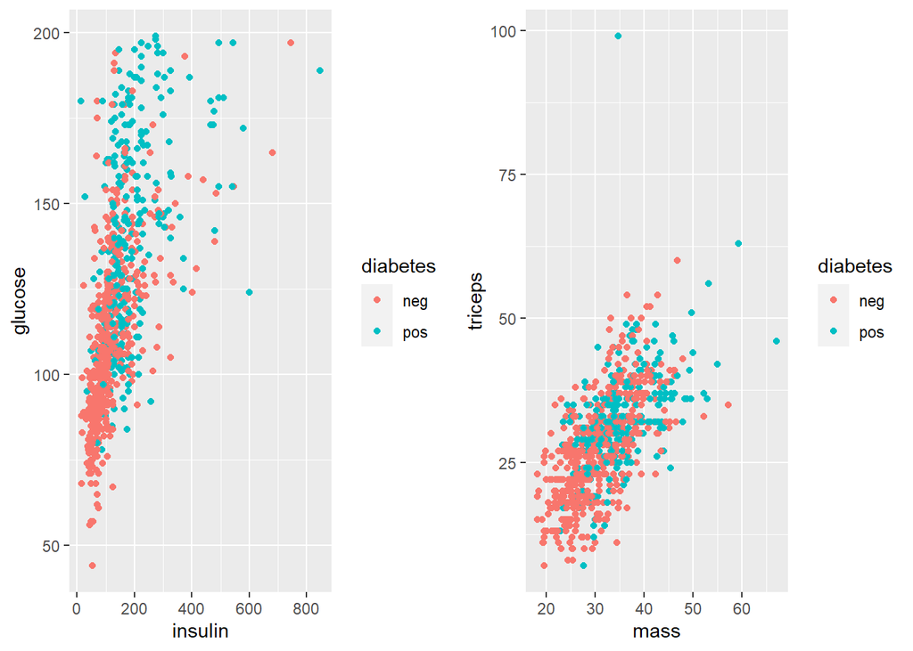

Figure 2.3: Scatter plots for ‘glucose’ and ‘insulin’, ‘mass’ and ‘triceps’

```r
ggp1<-ggplot(PimaIndiansDiabetes1,aes(x=insulin,y=glucose,col=diabetes))+geom_point()
ggp2<-ggplot(PimaIndiansDiabetes1,aes(x=mass,y=triceps,col=diabetes))+geom_point()
grid.arrange(ggp1,ggp2,ncol=2)
```

To give us a better understanding of each variable, different graphs (See Figure 2.4,2.5) were used to help with our preliminary findings.

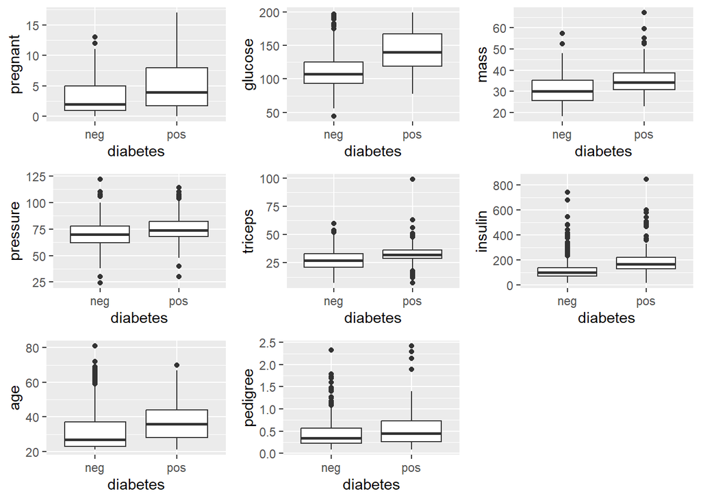

Figure 2.4: Box plots of diabetes against other variables

```r
plot1<-ggplot(PimaIndiansDiabetes1,aes(x=diabetes,y=pregnant))+geom_boxplot()
plot2<-ggplot(PimaIndiansDiabetes1,aes(x=diabetes,y=glucose))+geom_boxplot()
plot3<-ggplot(PimaIndiansDiabetes1,aes(x=diabetes,y=mass))+geom_boxplot()
plot4<-ggplot(PimaIndiansDiabetes1,aes(x=diabetes,y=pressure))+geom_boxplot()
plot5<-ggplot(PimaIndiansDiabetes1,aes(x=diabetes,y=triceps))+geom_boxplot()
plot6<-ggplot(PimaIndiansDiabetes1,aes(x=diabetes,y=insulin))+geom_boxplot()
plot7<-ggplot(PimaIndiansDiabetes1,aes(x=diabetes,y=age))+geom_boxplot()
plot8<-ggplot(PimaIndiansDiabetes1,aes(x=diabetes,y=pedigree))+geom_boxplot()
grid.arrange(plot1,plot2,plot3,plot4,plot5,plot6,plot7,plot8,ncol=3)
```

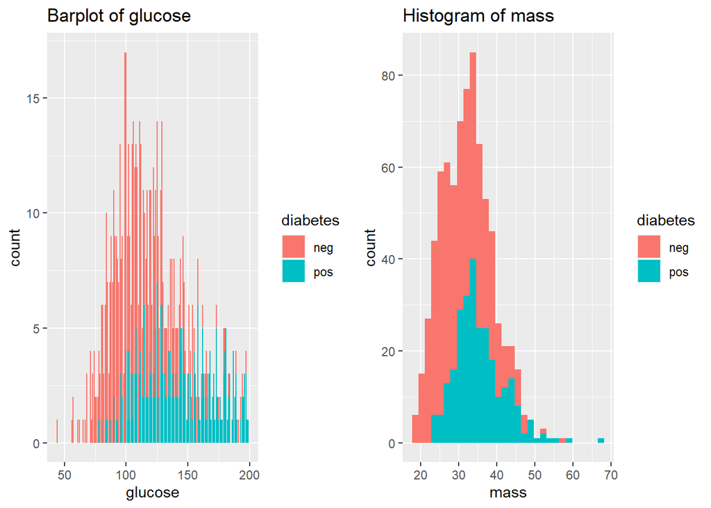

Figure 2.5: Glucose bar graph and Mass histogram

```r
glucosebar<-ggplot(PimaIndiansDiabetes1,aes(glucose,fill=diabetes))+ geom_bar() + ggtitle("Barplot of glucose")
masshist<-ggplot(PimaIndiansDiabetes1,aes(mass,fill=diabetes))+ geom_histogram() + ggtitle("Histogram of mass")
grid.arrange(glucosebar,masshist,ncol=2)
```

## 2.4 Methodology

In this section, we will deal with the machine learning techniques for prediction and classification. Linear regression was chosen for prediction as it provided a more explicit model form for interpretation and a well established statistical inference which allowed us to analyse which predicted variable had the most direct relation to the variable ‘glucose’ measuring glucose levels. Classification is used to specify the class to which data elements belong to. We worked with logistic regression as it relates with our main objective that is to determine which variables were most significant towards our categorical outcome variable, ‘diabetes’. To split our data into training and test sets, we applied the 80/20 splitting rule which randomly selected 80% of the data into the training set while the remaining was put into a test set.

```r
#Split data
set.seed(100)
training.idx <- sample(1: nrow(PimaIndiansDiabetes2), size=nrow(PimaIndiansDiabetes2)*0.8)
train.data  <-PimaIndiansDiabetes2[training.idx, ]
test.data <- PimaIndiansDiabetes2[-training.idx, ]
```

### 2.4.1 Prediction: Linear Regression

```r
#linear regression
lmodel<-lm(glucose~.,data=train.data)
summary(lmodel)
```

```
##
## Call:
## lm(formula = glucose ~ ., data = train.data)
##
## Residuals:
##     Min      1Q  Median      3Q     Max
## -80.817 -15.773  -2.161  11.254  76.539
##
## Coefficients:
##             Estimate Std. Error t value Pr(>|t|)
## (Intercept) 66.07027    6.83631   9.665   <2e-16 ***
## pregnant     0.14604    0.35084   0.416   0.6774
## pressure     0.20580    0.08997   2.288   0.0225 *
## triceps      0.15822    0.14476   1.093   0.2749
## insulin      0.17153    0.01071  16.012   <2e-16 ***
## mass         0.01868    0.20210   0.092   0.9264
## pedigree     2.19580    3.11888   0.704   0.4817
## age          0.25343    0.10516   2.410   0.0162 *
## ---
## Signif. codes:  0 '***' 0.001 '**' 0.01 '*' 0.05 '.' 0.1 ' ' 1
##
## Residual standard error: 23.95 on 606 degrees of freedom
## Multiple R-squared:  0.3872, Adjusted R-squared:  0.3802
## F-statistic: 54.71 on 7 and 606 DF,  p-value: < 2.2e-16
```

```r
predictions<-predict(lmodel,test.data)
RMSE(predictions,test.data$glucose)
```

```
## [1] 23.17604
```

```r
#RMSE value is 23.17604
```

```r
#kNN regression
set.seed(101)
model <- train(
  glucose~., data = train.data, method = "knn",
  trControl = trainControl("cv", number = 10),
  preProcess = c("center","scale"),
  tuneLength = 10
)
predictions <- predict(model, test.data)
head(predictions)
```

```
## [1] 141.9130 126.4348 120.7391 136.3478 104.4348 118.2174
```

```r
RMSE(predictions, test.data$glucose)
```

```
## [1] 23.53875
```

```r
#RMSE value is 23.53875
```

To interpret the statistics of the linear regression model, we make use of the number of * that indicates important impacts of predictors for ‘glucose’. The greater the number of asterisk, the higher the significance as a predictor. From Figure 2.6, we are able to see that insulin had the highest number of * indicating its significance. To add on, it also returned the lowest p-value and the highest positive coefficient (t-value) hence leading to us concluding that insulin had the highest significance with respect to glucose, which is accurate in the scientific context. Age and blood pressure can also be seen to follow after.

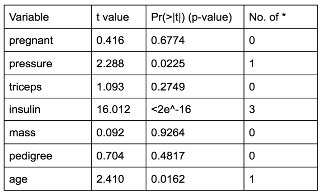

Figure 2.6: Summary table of data from Linear Regression

```r
knitr::include_graphics("C:/Users/Owner/OneDrive - Nanyang Technological University/Pictures/linear regression.png")
```

### 2.4.2 Classification:Logistic Regression

kNN for classification was considered but it was unable to interpret the effects of features in the classifier. Comparing the confusion matrix, the accuracy among Logistic, kNN and SVM methods were 79.22%, 75.32% and 77.27%. Thus, logistic regression was used as it had the highest percentage of points in the test set correctly classified. We will first convert the outcome variable ‘diabetes’ into 0,1 variable, where 0 represents ‘neg’ and 1 represents ‘pos’.

```r
#Convert outcome variable into 0,1 variable
PimaIndiansDiabetes1<-PimaIndiansDiabetes1%>%mutate(
  diabetes=factor(ifelse(diabetes=="pos", 1,0)))%>%
  select(pregnant:age, diabetes)
str(PimaIndiansDiabetes1)
```

```
## 'data.frame':    768 obs. of  9 variables:
##  $ pregnant: num  6 1 8 1 0 5 3 10 2 8 ...
##  $ glucose : num  148 85 183 89 137 116 78 115 197 125 ...
##  $ pressure: num  72 66 64 66 40 74 50 68 70 96 ...
##  $ triceps : num  35 29 28 23 35 27 32 39 45 36 ...
##  $ insulin : num  175 55 325 94 168 112 88 122 543 150 ...
##  $ mass    : num  33.6 26.6 23.3 28.1 43.1 25.6 31 35.3 30.5 32.7 ...
##  $ pedigree: num  0.627 0.351 0.672 0.167 2.288 ...
##  $ age     : num  50 31 32 21 33 30 26 29 53 54 ...
##  $ diabetes: Factor w/ 2 levels "0","1": 2 1 2 1 2 1 2 1 2 2 ...
```

```r
#split data
set.seed(100)
training.idx <- sample(1: nrow(PimaIndiansDiabetes1), size=nrow(PimaIndiansDiabetes1)*0.8)
train.data <-PimaIndiansDiabetes1[training.idx, ]
test.data <- PimaIndiansDiabetes1[-training.idx, ]

#logistic regression
mlogit <- glm(diabetes ~pregnant+glucose+mass+pedigree, data = train.data, family = "binomial")
summary(mlogit)
```

```
##
## Call:
## glm(formula = diabetes ~ pregnant + glucose + mass + pedigree,
##     family = "binomial", data = train.data)
##
## Deviance Residuals:
##     Min       1Q   Median       3Q      Max
## -2.7006  -0.7390  -0.4340   0.7655   2.3835
##
## Coefficients:
##              Estimate Std. Error z value Pr(>|z|)
## (Intercept) -8.469673   0.747529 -11.330  < 2e-16 ***
## pregnant     0.137797   0.030701   4.488 7.18e-06 ***
## glucose      0.035362   0.003794   9.319  < 2e-16 ***
## mass         0.074964   0.016162   4.638 3.51e-06 ***
## pedigree     0.781938   0.330850   2.363   0.0181 *
## ---
## Signif. codes:  0 '***' 0.001 '**' 0.01 '*' 0.05 '.' 0.1 ' ' 1
##
## (Dispersion parameter for binomial family taken to be 1)
##
##     Null deviance: 791.41  on 613  degrees of freedom
## Residual deviance: 590.92  on 609  degrees of freedom
## AIC: 600.92
##
## Number of Fisher Scoring iterations: 4
```

```r
Pred.p <-predict(mlogit, newdata =test.data, type = "response")
y_pred_num <-ifelse(Pred.p > 0.5, 1, 0)
y_pred <-factor(y_pred_num, levels=c(0, 1))
#Accuracy of the classification
mean(y_pred ==test.data$diabetes )
```

```
## [1] 0.7922078
```

```r
table(y_pred,test.data$diabetes)
```

```
##
## y_pred  0  1
##      0 89 23
##      1  9 33
```

```r
#0.7922078
```

```r
#kNN classification
library(class)
set.seed(101)
knn1<-knn(train.data, test.data, cl=train.data$diabetes, k=2)
mean(knn1 ==test.data$diabetes)
```

```
## [1] 0.7532468
```

```r
table(knn1,test.data$diabetes)
```

```
##
## knn1  0  1
##    0 79 19
##    1 19 37
```

```r
#0.7532468 (lower than logistic)
```

```r
#SVM
library(e1071)
set.seed(123)
m.svm.tune<-tune.svm(diabetes~., data=train.data, kernel="radial",cost=10^(-1:1), gamma=10^(-6:-1))
summary(m.svm.tune)
```

```
##
## Parameter tuning of 'svm':
##
## - sampling method: 10-fold cross validation
##
## - best parameters:
##  gamma cost
##    0.1   10
##
## - best performance: 0.2244844
##
## - Detailed performance results:
##    gamma cost     error dispersion
## 1  1e-06  0.1 0.3450555 0.06529146
## 2  1e-05  0.1 0.3450555 0.06529146
## 3  1e-04  0.1 0.3450555 0.06529146
## 4  1e-03  0.1 0.3450555 0.06529146
## 5  1e-02  0.1 0.3418562 0.06657035
## 6  1e-01  0.1 0.2456901 0.05349835
## 7  1e-06  1.0 0.3450555 0.06529146
## 8  1e-05  1.0 0.3450555 0.06529146
## 9  1e-04  1.0 0.3450555 0.06529146
## 10 1e-03  1.0 0.3239556 0.06787538
## 11 1e-02  1.0 0.2309625 0.05368699
## 12 1e-01  1.0 0.2292438 0.05678335
## 13 1e-06 10.0 0.3450555 0.06529146
## 14 1e-05 10.0 0.3450555 0.06529146
## 15 1e-04 10.0 0.3239556 0.07046555
## 16 1e-03 10.0 0.2423850 0.05313355
## 17 1e-02 10.0 0.2326282 0.04951371
## 18 1e-01 10.0 0.2244844 0.05042672
```

```r
best.svm = m.svm.tune$best.model
pred.svm.tune = predict(best.svm, newdata=test.data)
table(pred.svm.tune, test.data$diabetes)
```

```
##
## pred.svm.tune  0  1
##             0 89 26
##             1  9 30
```

```r
mean(pred.svm.tune ==test.data$diabetes)
```

```
## [1] 0.7727273
```

```r
#0.7727273
```

Logistic regression is then implemented and the summarized results are shown in Figure 2.7.

[figure not shown]

Figure 2.7: Summary table of data from Logistic Regression

```r
knitr::include_graphics("C:/Users/Owner/OneDrive - Nanyang Technological University/Pictures/Classification.png")
```

# 3 Conclusion

To achieve the main objective of the study, we came up with study questions for a more indepth research. Linear regression for prediction dealt with our second study question, which involved finding a variable that would most likely affect glucose directly since diabetes pertains to glucose levels. After conducting linear regression in R, we found ‘insulin’ levels to be the most significant in relation to ‘glucose’ according to the p and t values. Linear regression however is limited to linear relationships which might be inaccurate in the context of glucose and insulin as it is unlikely that their levels would increase linearly. To tackle this issue, we can consider adding polynomial terms to model the nonlinear relationship.

Hence, by applying the suggestions above to future research, it would return more realistic and appropriate values so as to achieve a more holistic and accurate overview of the results of our study.

# 4 References

1. C Bogardus.,S Lillioja. (1992). Pima Indians as a model to study the genetics of NIDDM. J Cell Biochem,48(4).https://pubmed.ncbi.nlm.nih.gov/1577873/
2. Newman, D.J. & Hettich, S. & Blake, C.L. & Merz, C.J. (1998). UCI Repository of machine learning databases [ http://www.ics.uci.edu/~mlearn/MLRepository.html ]. Irvine, CA: University of California, Department of Information and Computer Science.
3. Diabetes and Women. (2018, September 17). Centers for Disease Control and Prevention. https://www.cdc.gov/diabetes/library/features/diabetes-and-women.html
4. Diabetes in Singapore. (2021, January 18). Ministry Of Health. https://www.healthhub.sg/a-z/diseases-and-conditions/626/diabetes
5. Diabetes. (2021, April 13). World Health Organization. https://www.who.int/news-room/fact-sheets/detail/diabetes
6. Alexander K., Matthias T. (2016). Imputation with the R Package VIM.Journal of Statistical Software,74(7),7-9. https://www.jstatsoft.org/article/view/v074i07/v74i07.pdf